# IE582 - Homework 1

Ufuk Üstündağ

20 November 2020

# Installing Necessary Packages

```r
library(readxl)
library(data.table)
```

```r
library(stringr)
library(ggplot2)
```

# Inserting Data

```r
file.exists('C:/Users/ufuk9/Desktop/EngPL_20_21.xlsx')
```

```
## [1] TRUE
```

```r
file.exists('C:/Users/ufuk9/Desktop/EngPL_19_20.xlsx')
```

```
## [1] TRUE
```

```r
file.exists('C:/Users/ufuk9/Desktop/EngPL_18_19.xlsx')
```

```
## [1] TRUE
```

```r
datapath_20_21 = 'C:/Users/ufuk9/Desktop/EngPL_20_21.xlsx'
data_20_21 = read_excel(datapath_20_21)

datapath_19_20 = 'C:/Users/ufuk9/Desktop/EngPL_19_20.xlsx'
data_19_20 = read_excel(datapath_19_20)

datapath_18_19 = 'C:/Users/ufuk9/Desktop/EngPL_18_19.xlsx'
data_18_19 = read_excel(datapath_18_19)

data_20_21 = as.data.table(data_20_21)
data_19_20 = as.data.table(data_19_20)
data_18_19 = as.data.table(data_18_19)

PLdata <- rbind(data_18_19, data_19_20, data_20_21)
str(PLdata)
```

```
## Classes 'data.table' and 'data.frame':   838 obs. of  27 variables:
##  $ Div     : chr  "E0" "E0" "E0" "E0" ...
##  $ Date    : POSIXct, format: "2018-08-10" "2018-08-11" ...
##  $ HomeTeam: chr  "Man United" "Bournemouth" "Fulham" "Huddersfield" ...
##  $ AwayTeam: chr  "Leicester" "Cardiff" "Crystal Palace" "Chelsea" ...
##  $ FTHG    : num  2 2 0 0 1 2 2 0 4 0 ...
##  $ FTAG    : num  1 0 2 3 2 0 2 2 0 0 ...
##  $ FTR     : chr  "H" "H" "A" "A" ...
##  $ HR      : num  0 0 0 0 0 0 0 0 0 0 ...
##  $ AR      : num  0 0 0 0 0 0 1 0 0 0 ...
##  $ B365H   : num  1.57 1.9 2.5 6.5 3.9 2.37 2.37 4 1.25 1.85 ...
##  $ B365D   : num  3.9 3.6 3.4 4 3.5 3.2 3.3 3.8 6.5 3.5 ...
##  $ B365A   : num  7.5 4.5 3 1.61 2.04 3.4 3.3 1.95 14 5 ...
##  $ BWH     : num  1.53 1.9 2.45 6.25 3.8 2.35 2.35 3.7 1.2 1.8 ...
##  $ BWD     : num  4 3.4 3.3 3.9 3.5 3.1 3.2 3.75 6.75 3.5 ...
##  $ BWA     : num  7.5 4.4 2.95 1.57 2 3.3 3.2 1.95 14 4.75 ...
##  $ IWH     : num  1.55 1.9 2.4 6.2 3.7 2.2 2.25 3.6 1.25 1.8 ...
##  $ IWD     : num  3.8 3.5 3.3 4 3.35 3.3 3.35 3.6 6.1 3.6 ...
##  $ IWA     : num  7 4.1 2.95 1.55 2.05 3.4 3.2 2 11 4.5 ...
##  $ PSH     : num  1.58 1.89 2.5 6.41 3.83 2.43 2.36 4 1.27 1.86 ...
##  $ PSD     : num  3.93 3.63 3.46 4.02 3.57 3.22 3.4 3.97 6.35 3.51 ...
##  $ PSA     : num  7.5 4.58 3 1.62 2.08 ...
##  $ WHH     : num  1.57 1.91 2.45 5.8 3.8 2.38 2.3 3.8 1.25 1.83 ...
##  $ WHD     : num  3.8 3.5 3.3 3.9 3.2 3 3.2 3.8 5.5 3.25 ...
##  $ WHA     : num  6 4 2.8 1.57 2.05 3.3 3.2 1.91 12 4.8 ...
##  $ VCH     : num  1.57 1.87 2.5 6.5 3.9 2.4 2.38 3.9 1.25 1.85 ...
##  $ VCD     : num  4 3.6 3.4 4 3.4 3.2 3.3 4 6.5 3.4 ...
##  $ VCA     : num  7 4.75 3 1.62 2.1 3.4 3.3 1.91 13 5.2 ...
##  - attr(*, ".internal.selfref")=<externalptr>
```

## Task 1

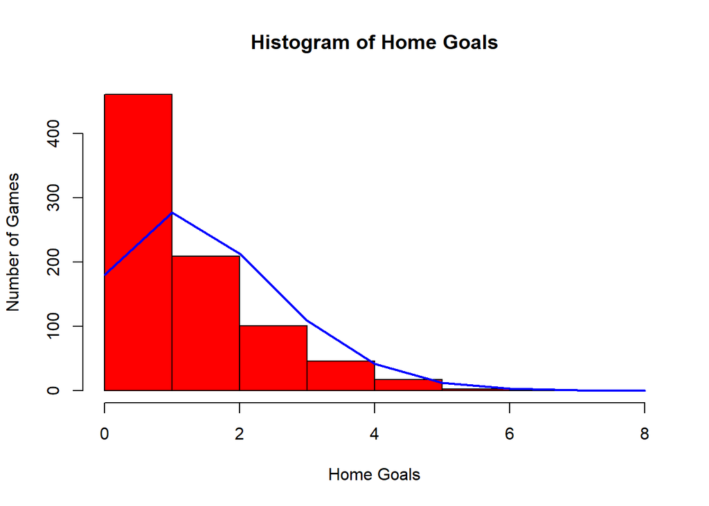

```r
h1 <- hist(PLdata$FTHG,col = "red", xlab = "Home Goals", ylab = "Number of Games", main = paste("Histogram of Home Goals"))

xfit1 <- seq(min(PLdata$FTHG), max(PLdata$FTHG))
yfit1 <- dpois(xfit1, lambda=mean(PLdata$FTHG))
yfit1 <- yfit1 * length(PLdata$FTHG)
lines(xfit1, yfit1, col="blue", lwd=2)
```

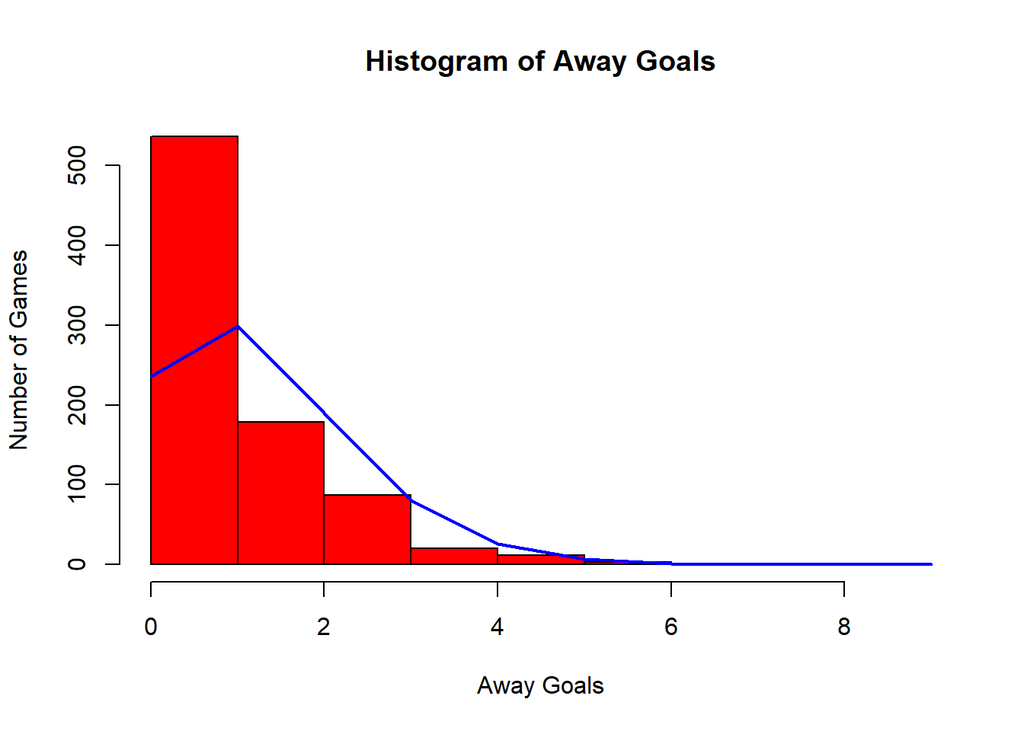

```r
h2 <- hist(PLdata$FTAG,col = "red", xlab = "Away Goals", ylab = "Number of Games", main = paste("Histogram of Away Goals"))

xfit2 <- seq(min(PLdata$FTAG), max(PLdata$FTAG))
yfit2 <- dpois(xfit2, lambda=mean(PLdata$FTAG))
yfit2 <- yfit2 * length(PLdata$FTAG)
lines(xfit2, yfit2, col="blue", lwd=2)
```

When the histograms are compared with the Poisson distribution curves, it is noticed that the results are pretty consistent except the zero score case. One can conclude that the Poisson distribution be a good guide for Home and Away scores.

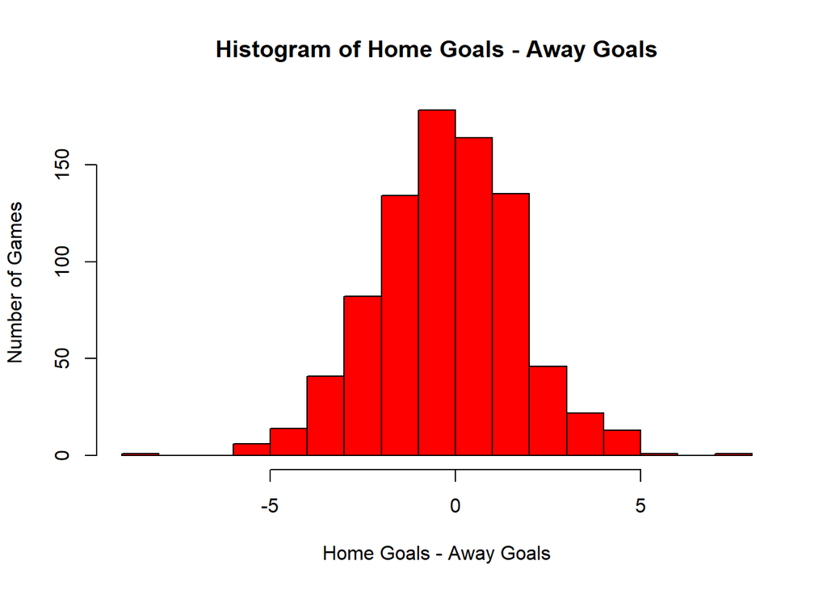

```r
h3 <- hist(PLdata$FTHG - PLdata$FTAG, breaks = -9:8, col = "red",
            xlab = "Home Goals - Away Goals", ylab = "Number of Games", main = paste("Histogram of Home Goals - Away Goals"))
```

## Task 2

### Q1) Finding probabilities for different bookmakers

```r
PLdata[, p_B365H := 1/B365H]
PLdata[, p_B365D := 1/B365D]
PLdata[, p_B365A := 1/B365A]

PLdata[, p_BWH := 1/BWH]
PLdata[, p_BWD := 1/BWD]
PLdata[, p_BWA := 1/BWA]

PLdata[, p_IWH := 1/IWH]
PLdata[, p_IWD := 1/IWD]
PLdata[, p_IWA := 1/IWA]

PLdata[, p_PSH := 1/PSH]
PLdata[, p_PSD := 1/PSD]
PLdata[, p_PSA := 1/PSA]
```

### Q2) Finding implied probabilities for different bookmakers

```r
PLdata[, imp_B365H := p_B365H/(p_B365H + p_B365D + p_B365A)]
PLdata[, imp_B365D := p_B365D/(p_B365H + p_B365D + p_B365A)]
PLdata[, imp_B365A := p_B365A/(p_B365H + p_B365D + p_B365A)]

PLdata[, imp_BWH := p_BWH/(p_BWH + p_BWD + p_BWA)]
PLdata[, imp_BWD := p_BWD/(p_BWH + p_BWD + p_BWA)]
PLdata[, imp_BWA := p_BWA/(p_BWH + p_BWD + p_BWA)]

PLdata[, imp_IWH := p_IWH/(p_IWH + p_IWD + p_IWA)]
PLdata[, imp_IWD := p_IWD/(p_IWH + p_IWD + p_IWA)]
PLdata[, imp_IWA := p_IWA/(p_IWH + p_IWD + p_IWA)]

PLdata[, imp_PSH := p_PSH/(p_PSH + p_PSD + p_PSA)]
PLdata[, imp_PSD := p_PSD/(p_PSH + p_PSD + p_PSA)]
PLdata[, imp_PSA := p_PSA/(p_PSH + p_PSD + p_PSA)]

str(PLdata)
```

```
## Classes 'data.table' and 'data.frame':   838 obs. of  51 variables:
##  $ Div      : chr  "E0" "E0" "E0" "E0" ...
##  $ Date     : POSIXct, format: "2018-08-10" "2018-08-11" ...
##  $ HomeTeam : chr  "Man United" "Bournemouth" "Fulham" "Huddersfield" ...
##  $ AwayTeam : chr  "Leicester" "Cardiff" "Crystal Palace" "Chelsea" ...
##  $ FTHG     : num  2 2 0 0 1 2 2 0 4 0 ...
##  $ FTAG     : num  1 0 2 3 2 0 2 2 0 0 ...
##  $ FTR      : chr  "H" "H" "A" "A" ...
##  $ HR       : num  0 0 0 0 0 0 0 0 0 0 ...
##  $ AR       : num  0 0 0 0 0 0 1 0 0 0 ...
##  $ B365H    : num  1.57 1.9 2.5 6.5 3.9 2.37 2.37 4 1.25 1.85 ...
##  $ B365D    : num  3.9 3.6 3.4 4 3.5 3.2 3.3 3.8 6.5 3.5 ...
##  $ B365A    : num  7.5 4.5 3 1.61 2.04 3.4 3.3 1.95 14 5 ...
##  $ BWH      : num  1.53 1.9 2.45 6.25 3.8 2.35 2.35 3.7 1.2 1.8 ...
##  $ BWD      : num  4 3.4 3.3 3.9 3.5 3.1 3.2 3.75 6.75 3.5 ...
```

[output cut: 38 more lines]

### Q3 and Q4)

#### B365

```r
PLdata[, HAdiff_B365 := p_B365H - p_B365A]

count_bin1 <- sum(PLdata$HAdiff_B365 <= -0.8)
count_bin2 <- sum(PLdata$HAdiff_B365 > -0.8 & PLdata$HAdiff_B365 <= -0.6)
count_bin3 <- sum(PLdata$HAdiff_B365 > -0.6 & PLdata$HAdiff_B365 <= -0.4)
count_bin4 <- sum(PLdata$HAdiff_B365 > -0.4 & PLdata$HAdiff_B365 <= -0.2)
count_bin5 <- sum(PLdata$HAdiff_B365 > -0.2 & PLdata$HAdiff_B365 <= 0)
count_bin6 <- sum(PLdata$HAdiff_B365 > 0 & PLdata$HAdiff_B365 <= 0.2)
count_bin7 <- sum(PLdata$HAdiff_B365 > 0.2 & PLdata$HAdiff_B365 <= 0.4)
count_bin8 <- sum(PLdata$HAdiff_B365 > 0.4 & PLdata$HAdiff_B365 <= 0.6)
count_bin9 <- sum(PLdata$HAdiff_B365 > 0.6 & PLdata$HAdiff_B365 <= 0.8)
count_bin10 <- sum(PLdata$HAdiff_B365 > 0.8)

prob_bin1 <- sum(PLdata$HAdiff_B365 <= -0.8 & PLdata$FTR == "D") / count_bin1
prob_bin2 <- sum(PLdata$HAdiff_B365 > -0.8 & PLdata$HAdiff_B365 <= -0.6 & PLdata$FTR == "D") / count_bin2
prob_bin3 <- sum(PLdata$HAdiff_B365 > -0.6 & PLdata$HAdiff_B365 <= -0.4 & PLdata$FTR == "D") / count_bin3
prob_bin4 <- sum(PLdata$HAdiff_B365 > -0.4 & PLdata$HAdiff_B365 <= -0.2 & PLdata$FTR == "D") / count_bin4
prob_bin5 <- sum(PLdata$HAdiff_B365 > -0.2 & PLdata$HAdiff_B365 <= 0 & PLdata$FTR == "D") / count_bin5
prob_bin6 <- sum(PLdata$HAdiff_B365 > 0 & PLdata$HAdiff_B365 <= 0.2 & PLdata$FTR == "D") / count_bin6
prob_bin7 <- sum(PLdata$HAdiff_B365 > 0.2 & PLdata$HAdiff_B365 <= 0.4 & PLdata$FTR == "D") / count_bin7
prob_bin8 <- sum(PLdata$HAdiff_B365 > 0.4 & PLdata$HAdiff_B365 <= 0.6 & PLdata$FTR == "D") / count_bin8
prob_bin9 <- sum(PLdata$HAdiff_B365 > 0.6 & PLdata$HAdiff_B365 <= 0.8 & PLdata$FTR == "D") / count_bin9
prob_bin10 <- sum(PLdata$HAdiff_B365 > 0.8 & PLdata$FTR == "D") / count_bin10

PLdata[, bin_draw_prob_B365 := 2]

for( i in 1 : nrow(PLdata))
{
if(PLdata$HAdiff_B365[i] <= -0.8) {PLdata$bin_draw_prob_B365[i] = prob_bin1}
else if(PLdata$HAdiff_B365[i] > -0.8 & PLdata$HAdiff_B365[i] <= -0.6) {PLdata$bin_draw_prob_B365[i] = prob_bin2}
else if(PLdata$HAdiff_B365[i] > -0.6 & PLdata$HAdiff_B365[i] <= -0.4) {PLdata$bin_draw_prob_B365[i] = prob_bin3}
else if(PLdata$HAdiff_B365[i] > -0.4 & PLdata$HAdiff_B365[i]<= -0.2) {PLdata$bin_draw_prob_B365[i] = prob_bin4}
else if(PLdata$HAdiff_B365[i] > -0.2 & PLdata$HAdiff_B365[i] <= -0) {PLdata$bin_draw_prob_B365[i] = prob_bin5}
else if(PLdata$HAdiff_B365[i] > 0 & PLdata$HAdiff_B365[i] <= 0.2) {PLdata$bin_draw_prob_B365[i] = prob_bin6}
else if(PLdata$HAdiff_B365[i] > 0.2 & PLdata$HAdiff_B365[i] <= 0.4) {PLdata$bin_draw_prob_B365[i] = prob_bin7}
else if(PLdata$HAdiff_B365[i] > 0.4 & PLdata$HAdiff_B365[i] <= 0.6) {PLdata$bin_draw_prob_B365[i] = prob_bin8}
else if(PLdata$HAdiff_B365[i] > 0.6 & PLdata$HAdiff_B365[i] <= 0.8) {PLdata$bin_draw_prob_B365[i] = prob_bin9}
else if(PLdata$HAdiff_B365[i] > 0.8) {PLdata$bin_draw_prob_B365[i] = prob_bin10}
}
```

#### BW

```r
PLdata[, HAdiff_BW := p_BWH - p_BWA]

count_bin1 <- sum(PLdata$HAdiff_BW <= -0.8)
count_bin2 <- sum(PLdata$HAdiff_BW > -0.8 & PLdata$HAdiff_BW <= -0.6)
count_bin3 <- sum(PLdata$HAdiff_BW > -0.6 & PLdata$HAdiff_BW <= -0.4)
count_bin4 <- sum(PLdata$HAdiff_BW > -0.4 & PLdata$HAdiff_BW <= -0.2)
count_bin5 <- sum(PLdata$HAdiff_BW > -0.2 & PLdata$HAdiff_BW <= 0)
count_bin6 <- sum(PLdata$HAdiff_BW > 0 & PLdata$HAdiff_BW <= 0.2)
count_bin7 <- sum(PLdata$HAdiff_BW > 0.2 & PLdata$HAdiff_BW <= 0.4)
count_bin8 <- sum(PLdata$HAdiff_BW > 0.4 & PLdata$HAdiff_BW <= 0.6)
count_bin9 <- sum(PLdata$HAdiff_BW > 0.6 & PLdata$HAdiff_BW <= 0.8)
count_bin10 <- sum(PLdata$HAdiff_BW > 0.8)

prob_bin1 <- sum(PLdata$HAdiff_BW <= -0.8 & PLdata$FTR == "D") / count_bin1
prob_bin2 <- sum(PLdata$HAdiff_BW > -0.8 & PLdata$HAdiff_BW <= -0.6 & PLdata$FTR == "D") / count_bin2
prob_bin3 <- sum(PLdata$HAdiff_BW > -0.6 & PLdata$HAdiff_BW <= -0.4 & PLdata$FTR == "D") / count_bin3
prob_bin4 <- sum(PLdata$HAdiff_BW > -0.4 & PLdata$HAdiff_BW <= -0.2 & PLdata$FTR == "D") / count_bin4
prob_bin5 <- sum(PLdata$HAdiff_BW > -0.2 & PLdata$HAdiff_BW <= 0 & PLdata$FTR == "D") / count_bin5
prob_bin6 <- sum(PLdata$HAdiff_BW > 0 & PLdata$HAdiff_BW <= 0.2 & PLdata$FTR == "D") / count_bin6
prob_bin7 <- sum(PLdata$HAdiff_BW > 0.2 & PLdata$HAdiff_BW <= 0.4 & PLdata$FTR == "D") / count_bin7
prob_bin8 <- sum(PLdata$HAdiff_BW > 0.4 & PLdata$HAdiff_BW <= 0.6 & PLdata$FTR == "D") / count_bin8
prob_bin9 <- sum(PLdata$HAdiff_BW > 0.6 & PLdata$HAdiff_BW <= 0.8 & PLdata$FTR == "D") / count_bin9
prob_bin10 <- sum(PLdata$HAdiff_BW > 0.8 & PLdata$FTR == "D") / count_bin10

PLdata[, bin_draw_prob_BW := 2]

for( i in 1 : nrow(PLdata))
{
  if(PLdata$HAdiff_BW[i] <= -0.8) {PLdata$bin_draw_prob_BW[i] = prob_bin1}
  else if(PLdata$HAdiff_BW[i] > -0.8 & PLdata$HAdiff_BW[i] <= -0.6) {PLdata$bin_draw_prob_BW[i] = prob_bin2}
  else if(PLdata$HAdiff_BW[i] > -0.6 & PLdata$HAdiff_BW[i] <= -0.4) {PLdata$bin_draw_prob_BW[i] = prob_bin3}
  else if(PLdata$HAdiff_BW[i] > -0.4 & PLdata$HAdiff_BW[i]<= -0.2) {PLdata$bin_draw_prob_BW[i] = prob_bin4}
  else if(PLdata$HAdiff_BW[i] > -0.2 & PLdata$HAdiff_BW[i] <= -0) {PLdata$bin_draw_prob_BW[i] = prob_bin5}
  else if(PLdata$HAdiff_BW[i] > 0 & PLdata$HAdiff_BW[i] <= 0.2) {PLdata$bin_draw_prob_BW[i] = prob_bin6}
  else if(PLdata$HAdiff_BW[i] > 0.2 & PLdata$HAdiff_BW[i] <= 0.4) {PLdata$bin_draw_prob_BW[i] = prob_bin7}
  else if(PLdata$HAdiff_BW[i] > 0.4 & PLdata$HAdiff_BW[i] <= 0.6) {PLdata$bin_draw_prob_BW[i] = prob_bin8}
  else if(PLdata$HAdiff_BW[i] > 0.6 & PLdata$HAdiff_BW[i] <= 0.8) {PLdata$bin_draw_prob_BW[i] = prob_bin9}
  else if(PLdata$HAdiff_BW[i] > 0.8) {PLdata$bin_draw_prob_BW[i] = prob_bin10}
}
```

#### IW

```r
PLdata[, HAdiff_IW := p_IWH - p_IWA]

count_bin1 <- sum(PLdata$HAdiff_IW <= -0.8)
count_bin2 <- sum(PLdata$HAdiff_IW > -0.8 & PLdata$HAdiff_IW <= -0.6)
count_bin3 <- sum(PLdata$HAdiff_IW > -0.6 & PLdata$HAdiff_IW <= -0.4)
count_bin4 <- sum(PLdata$HAdiff_IW > -0.4 & PLdata$HAdiff_IW <= -0.2)
count_bin5 <- sum(PLdata$HAdiff_IW > -0.2 & PLdata$HAdiff_IW <= 0)
count_bin6 <- sum(PLdata$HAdiff_IW > 0 & PLdata$HAdiff_IW <= 0.2)
count_bin7 <- sum(PLdata$HAdiff_IW > 0.2 & PLdata$HAdiff_IW <= 0.4)
count_bin8 <- sum(PLdata$HAdiff_IW > 0.4 & PLdata$HAdiff_IW <= 0.6)
count_bin9 <- sum(PLdata$HAdiff_IW > 0.6 & PLdata$HAdiff_IW <= 0.8)
count_bin10 <- sum(PLdata$HAdiff_IW > 0.8)

prob_bin1 <- sum(PLdata$HAdiff_IW <= -0.8 & PLdata$FTR == "D") / count_bin1
prob_bin2 <- sum(PLdata$HAdiff_IW > -0.8 & PLdata$HAdiff_IW <= -0.6 & PLdata$FTR == "D") / count_bin2
prob_bin3 <- sum(PLdata$HAdiff_IW > -0.6 & PLdata$HAdiff_IW <= -0.4 & PLdata$FTR == "D") / count_bin3
prob_bin4 <- sum(PLdata$HAdiff_IW > -0.4 & PLdata$HAdiff_IW <= -0.2 & PLdata$FTR == "D") / count_bin4
prob_bin5 <- sum(PLdata$HAdiff_IW > -0.2 & PLdata$HAdiff_IW <= 0 & PLdata$FTR == "D") / count_bin5
prob_bin6 <- sum(PLdata$HAdiff_IW > 0 & PLdata$HAdiff_IW <= 0.2 & PLdata$FTR == "D") / count_bin6
prob_bin7 <- sum(PLdata$HAdiff_IW > 0.2 & PLdata$HAdiff_IW <= 0.4 & PLdata$FTR == "D") / count_bin7
prob_bin8 <- sum(PLdata$HAdiff_IW > 0.4 & PLdata$HAdiff_IW <= 0.6 & PLdata$FTR == "D") / count_bin8
prob_bin9 <- sum(PLdata$HAdiff_IW > 0.6 & PLdata$HAdiff_IW <= 0.8 & PLdata$FTR == "D") / count_bin9
prob_bin10 <- sum(PLdata$HAdiff_IW > 0.8 & PLdata$FTR == "D") / count_bin10

PLdata[, bin_draw_prob_IW := 2]

for( i in 1 : nrow(PLdata))
{
  if(PLdata$HAdiff_IW[i] <= -0.8) {PLdata$bin_draw_prob_IW[i] = prob_bin1}
  else if(PLdata$HAdiff_IW[i] > -0.8 & PLdata$HAdiff_IW[i] <= -0.6) {PLdata$bin_draw_prob_IW[i] = prob_bin2}
  else if(PLdata$HAdiff_IW[i] > -0.6 & PLdata$HAdiff_IW[i] <= -0.4) {PLdata$bin_draw_prob_IW[i] = prob_bin3}
  else if(PLdata$HAdiff_IW[i] > -0.4 & PLdata$HAdiff_IW[i]<= -0.2) {PLdata$bin_draw_prob_IW[i] = prob_bin4}
  else if(PLdata$HAdiff_IW[i] > -0.2 & PLdata$HAdiff_IW[i] <= -0) {PLdata$bin_draw_prob_IW[i] = prob_bin5}
  else if(PLdata$HAdiff_IW[i] > 0 & PLdata$HAdiff_IW[i] <= 0.2) {PLdata$bin_draw_prob_IW[i] = prob_bin6}
  else if(PLdata$HAdiff_IW[i] > 0.2 & PLdata$HAdiff_IW[i] <= 0.4) {PLdata$bin_draw_prob_IW[i] = prob_bin7}
  else if(PLdata$HAdiff_IW[i] > 0.4 & PLdata$HAdiff_IW[i] <= 0.6) {PLdata$bin_draw_prob_IW[i] = prob_bin8}
  else if(PLdata$HAdiff_IW[i] > 0.6 & PLdata$HAdiff_IW[i] <= 0.8) {PLdata$bin_draw_prob_IW[i] = prob_bin9}
  else if(PLdata$HAdiff_IW[i] > 0.8) {PLdata$bin_draw_prob_IW[i] = prob_bin10}
}
```

#### PS

```r
PLdata[, HAdiff_PS := p_PSH - p_PSA]

count_bin1 <- sum(PLdata$HAdiff_PS <= -0.8)
count_bin2 <- sum(PLdata$HAdiff_PS > -0.8 & PLdata$HAdiff_PS <= -0.6)
count_bin3 <- sum(PLdata$HAdiff_PS > -0.6 & PLdata$HAdiff_PS <= -0.4)
count_bin4 <- sum(PLdata$HAdiff_PS > -0.4 & PLdata$HAdiff_PS <= -0.2)
count_bin5 <- sum(PLdata$HAdiff_PS > -0.2 & PLdata$HAdiff_PS <= 0)
count_bin6 <- sum(PLdata$HAdiff_PS > 0 & PLdata$HAdiff_PS <= 0.2)
count_bin7 <- sum(PLdata$HAdiff_PS > 0.2 & PLdata$HAdiff_PS <= 0.4)
count_bin8 <- sum(PLdata$HAdiff_PS > 0.4 & PLdata$HAdiff_PS <= 0.6)
count_bin9 <- sum(PLdata$HAdiff_PS > 0.6 & PLdata$HAdiff_PS <= 0.8)
count_bin10 <- sum(PLdata$HAdiff_PS > 0.8)

prob_bin1 <- sum(PLdata$HAdiff_PS <= -0.8 & PLdata$FTR == "D") / count_bin1
prob_bin2 <- sum(PLdata$HAdiff_PS > -0.8 & PLdata$HAdiff_PS <= -0.6 & PLdata$FTR == "D") / count_bin2
prob_bin3 <- sum(PLdata$HAdiff_PS > -0.6 & PLdata$HAdiff_PS <= -0.4 & PLdata$FTR == "D") / count_bin3
prob_bin4 <- sum(PLdata$HAdiff_PS > -0.4 & PLdata$HAdiff_PS <= -0.2 & PLdata$FTR == "D") / count_bin4
prob_bin5 <- sum(PLdata$HAdiff_PS > -0.2 & PLdata$HAdiff_PS <= 0 & PLdata$FTR == "D") / count_bin5
prob_bin6 <- sum(PLdata$HAdiff_PS > 0 & PLdata$HAdiff_PS <= 0.2 & PLdata$FTR == "D") / count_bin6
prob_bin7 <- sum(PLdata$HAdiff_PS > 0.2 & PLdata$HAdiff_PS <= 0.4 & PLdata$FTR == "D") / count_bin7
prob_bin8 <- sum(PLdata$HAdiff_PS > 0.4 & PLdata$HAdiff_PS <= 0.6 & PLdata$FTR == "D") / count_bin8
prob_bin9 <- sum(PLdata$HAdiff_PS > 0.6 & PLdata$HAdiff_PS <= 0.8 & PLdata$FTR == "D") / count_bin9
prob_bin10 <- sum(PLdata$HAdiff_PS > 0.8 & PLdata$FTR == "D") / count_bin10

PLdata[, bin_draw_prob_PS := 2]

for( i in 1 : nrow(PLdata))
{
  if(PLdata$HAdiff_PS[i] <= -0.8) {PLdata$bin_draw_prob_PS[i] = prob_bin1}
  else if(PLdata$HAdiff_PS[i] > -0.8 & PLdata$HAdiff_PS[i] <= -0.6) {PLdata$bin_draw_prob_PS[i] = prob_bin2}
  else if(PLdata$HAdiff_PS[i] > -0.6 & PLdata$HAdiff_PS[i] <= -0.4) {PLdata$bin_draw_prob_PS[i] = prob_bin3}
  else if(PLdata$HAdiff_PS[i] > -0.4 & PLdata$HAdiff_PS[i]<= -0.2) {PLdata$bin_draw_prob_PS[i] = prob_bin4}
  else if(PLdata$HAdiff_PS[i] > -0.2 & PLdata$HAdiff_PS[i] <= -0) {PLdata$bin_draw_prob_PS[i] = prob_bin5}
  else if(PLdata$HAdiff_PS[i] > 0 & PLdata$HAdiff_PS[i] <= 0.2) {PLdata$bin_draw_prob_PS[i] = prob_bin6}
  else if(PLdata$HAdiff_PS[i] > 0.2 & PLdata$HAdiff_PS[i] <= 0.4) {PLdata$bin_draw_prob_PS[i] = prob_bin7}
  else if(PLdata$HAdiff_PS[i] > 0.4 & PLdata$HAdiff_PS[i] <= 0.6) {PLdata$bin_draw_prob_PS[i] = prob_bin8}
  else if(PLdata$HAdiff_PS[i] > 0.6 & PLdata$HAdiff_PS[i] <= 0.8) {PLdata$bin_draw_prob_PS[i] = prob_bin9}
  else if(PLdata$HAdiff_PS[i] > 0.8) {PLdata$bin_draw_prob_PS[i] = prob_bin10}
}
```

### Plots

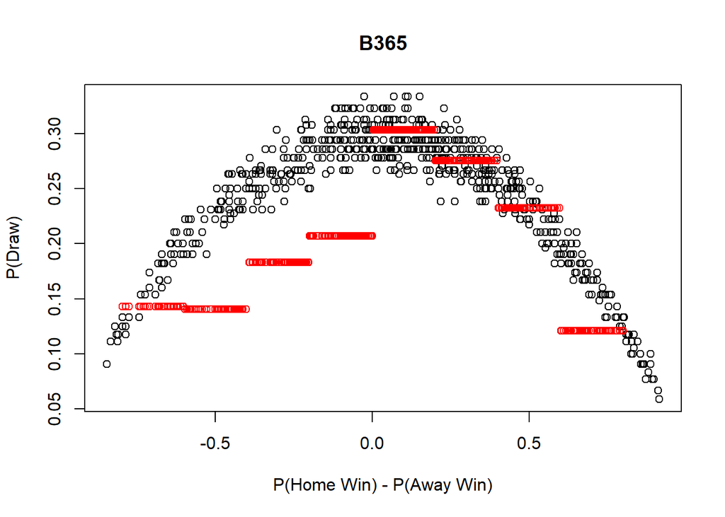

```r
plot(x = (PLdata$HAdiff_B365), y = PLdata$p_B365D,
     xlab = "P(Home Win) - P(Away Win)", ylab = "P(Draw)", main = "B365")
points(x = PLdata$HAdiff_B365, y = PLdata$bin_draw_prob_B365, col = "red")
```

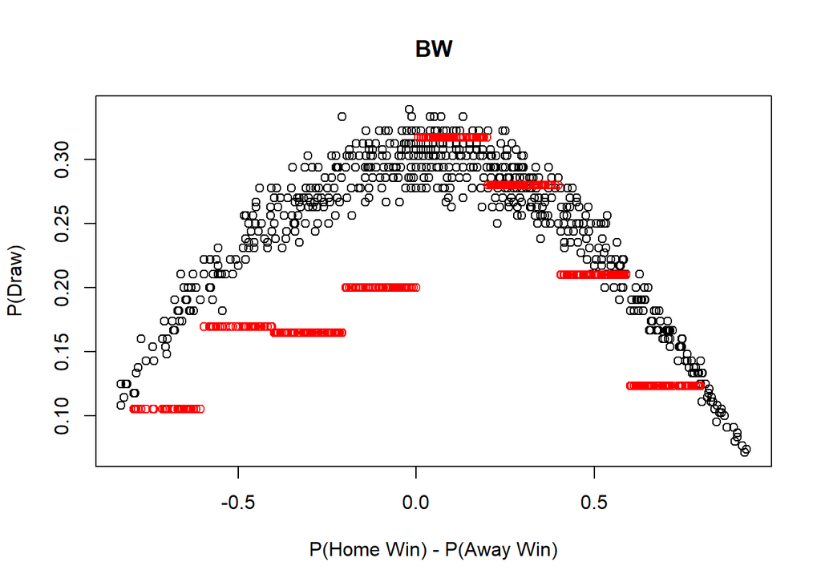

```r
plot(x = (PLdata$HAdiff_BW), y = PLdata$p_BWD,
     xlab = "P(Home Win) - P(Away Win)", ylab = "P(Draw)", main = "BW")
points(x = PLdata$HAdiff_BW, y = PLdata$bin_draw_prob_BW, col = "red")
```

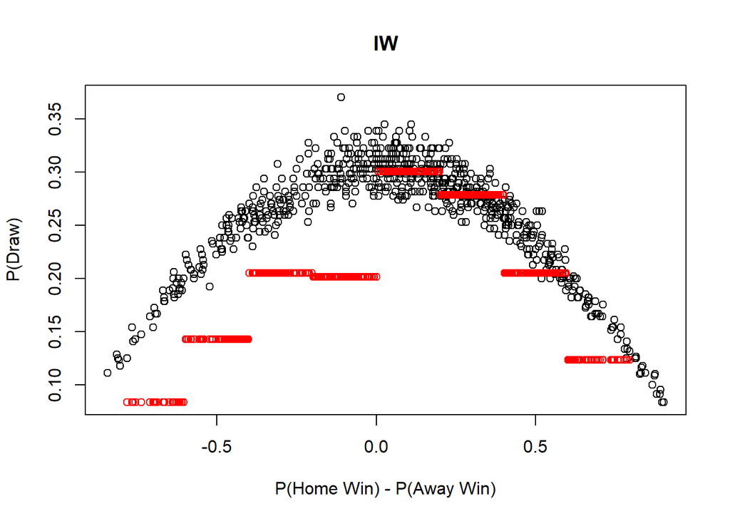

```r
plot(x = (PLdata$HAdiff_IW), y = PLdata$p_IWD,
     xlab = "P(Home Win) - P(Away Win)", ylab = "P(Draw)", main = "IW")
points(x = PLdata$HAdiff_IW, y = PLdata$bin_draw_prob_IW, col = "red")
```

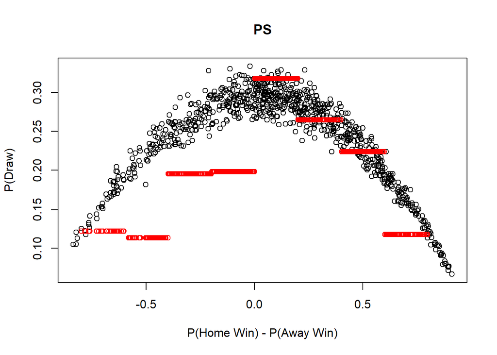

```r
plot(x = (PLdata$HAdiff_PS), y = PLdata$p_PSD,
     xlab = "P(Home Win) - P(Away Win)", ylab = "P(Draw)", main = "PS")
points(x = PLdata$HAdiff_PS, y = PLdata$bin_draw_prob_PS, col = "red")
```

The fact that the probabilities are represented by 1/odds creats a bias in terms of bookmakers’ interpretations on probabilities However, if one is interested in determining whether or not s/he can make profit by betting on the matches in particular bins, 1/odds must be used since bookmakers are favored in the betting business. On the other hand, if a person is interested in knowing if s/he can make better guesses than the bookmakers at certain bins, normalized probabilities should be used.

## Task 3

```r
PLdata_rem <- PLdata
PLdata_rem <- PLdata_rem[-which(PLdata_rem$HR > 0 | PLdata_rem$AR > 0),]
```

### Q3 and Q4)

#### B365

```r
PLdata_rem[, HAdiff_B365 := p_B365H - p_B365A]

count_bin1 <- sum(PLdata_rem$HAdiff_B365 <= -0.8)
count_bin2 <- sum(PLdata_rem$HAdiff_B365 > -0.8 & PLdata_rem$HAdiff_B365 <= -0.6)
count_bin3 <- sum(PLdata_rem$HAdiff_B365 > -0.6 & PLdata_rem$HAdiff_B365 <= -0.4)
count_bin4 <- sum(PLdata_rem$HAdiff_B365 > -0.4 & PLdata_rem$HAdiff_B365 <= -0.2)
count_bin5 <- sum(PLdata_rem$HAdiff_B365 > -0.2 & PLdata_rem$HAdiff_B365 <= 0)
count_bin6 <- sum(PLdata_rem$HAdiff_B365 > 0 & PLdata_rem$HAdiff_B365 <= 0.2)
count_bin7 <- sum(PLdata_rem$HAdiff_B365 > 0.2 & PLdata_rem$HAdiff_B365 <= 0.4)
count_bin8 <- sum(PLdata_rem$HAdiff_B365 > 0.4 & PLdata_rem$HAdiff_B365 <= 0.6)
count_bin9 <- sum(PLdata_rem$HAdiff_B365 > 0.6 & PLdata_rem$HAdiff_B365 <= 0.8)
count_bin10 <- sum(PLdata_rem$HAdiff_B365 > 0.8)

prob_bin1 <- sum(PLdata_rem$HAdiff_B365 <= -0.8 & PLdata_rem$FTR == "D") / count_bin1
prob_bin2 <- sum(PLdata_rem$HAdiff_B365 > -0.8 & PLdata_rem$HAdiff_B365 <= -0.6 & PLdata_rem$FTR == "D") / count_bin2
prob_bin3 <- sum(PLdata_rem$HAdiff_B365 > -0.6 & PLdata_rem$HAdiff_B365 <= -0.4 & PLdata_rem$FTR == "D") / count_bin3
prob_bin4 <- sum(PLdata_rem$HAdiff_B365 > -0.4 & PLdata_rem$HAdiff_B365 <= -0.2 & PLdata_rem$FTR == "D") / count_bin4
prob_bin5 <- sum(PLdata_rem$HAdiff_B365 > -0.2 & PLdata_rem$HAdiff_B365 <= 0 & PLdata_rem$FTR == "D") / count_bin5
prob_bin6 <- sum(PLdata_rem$HAdiff_B365 > 0 & PLdata_rem$HAdiff_B365 <= 0.2 & PLdata_rem$FTR == "D") / count_bin6
prob_bin7 <- sum(PLdata_rem$HAdiff_B365 > 0.2 & PLdata_rem$HAdiff_B365 <= 0.4 & PLdata_rem$FTR == "D") / count_bin7
prob_bin8 <- sum(PLdata_rem$HAdiff_B365 > 0.4 & PLdata_rem$HAdiff_B365 <= 0.6 & PLdata_rem$FTR == "D") / count_bin8
prob_bin9 <- sum(PLdata_rem$HAdiff_B365 > 0.6 & PLdata_rem$HAdiff_B365 <= 0.8 & PLdata_rem$FTR == "D") / count_bin9
prob_bin10 <- sum(PLdata_rem$HAdiff_B365 > 0.8 & PLdata_rem$FTR == "D") / count_bin10

PLdata_rem[, bin_draw_prob_B365 := 2]

for( i in 1 : nrow(PLdata_rem))
{
  if(PLdata_rem$HAdiff_B365[i] <= -0.8) {PLdata_rem$bin_draw_prob_B365[i] = prob_bin1}
  else if(PLdata_rem$HAdiff_B365[i] > -0.8 & PLdata_rem$HAdiff_B365[i] <= -0.6) {PLdata_rem$bin_draw_prob_B365[i] = prob_bin2}
  else if(PLdata_rem$HAdiff_B365[i] > -0.6 & PLdata_rem$HAdiff_B365[i] <= -0.4) {PLdata_rem$bin_draw_prob_B365[i] = prob_bin3}
  else if(PLdata_rem$HAdiff_B365[i] > -0.4 & PLdata_rem$HAdiff_B365[i]<= -0.2) {PLdata_rem$bin_draw_prob_B365[i] = prob_bin4}
  else if(PLdata_rem$HAdiff_B365[i] > -0.2 & PLdata_rem$HAdiff_B365[i] <= -0) {PLdata_rem$bin_draw_prob_B365[i] = prob_bin5}
  else if(PLdata_rem$HAdiff_B365[i] > 0 & PLdata_rem$HAdiff_B365[i] <= 0.2) {PLdata_rem$bin_draw_prob_B365[i] = prob_bin6}
  else if(PLdata_rem$HAdiff_B365[i] > 0.2 & PLdata_rem$HAdiff_B365[i] <= 0.4) {PLdata_rem$bin_draw_prob_B365[i] = prob_bin7}
  else if(PLdata_rem$HAdiff_B365[i] > 0.4 & PLdata_rem$HAdiff_B365[i] <= 0.6) {PLdata_rem$bin_draw_prob_B365[i] = prob_bin8}
  else if(PLdata_rem$HAdiff_B365[i] > 0.6 & PLdata_rem$HAdiff_B365[i] <= 0.8) {PLdata_rem$bin_draw_prob_B365[i] = prob_bin9}
  else if(PLdata_rem$HAdiff_B365[i] > 0.8) {PLdata_rem$bin_draw_prob_B365[i] = prob_bin10}
}
```

#### BW

```r
PLdata_rem[, HAdiff_BW := p_BWH - p_BWA]

count_bin1 <- sum(PLdata_rem$HAdiff_BW <= -0.8)
count_bin2 <- sum(PLdata_rem$HAdiff_BW > -0.8 & PLdata_rem$HAdiff_BW <= -0.6)
count_bin3 <- sum(PLdata_rem$HAdiff_BW > -0.6 & PLdata_rem$HAdiff_BW <= -0.4)
count_bin4 <- sum(PLdata_rem$HAdiff_BW > -0.4 & PLdata_rem$HAdiff_BW <= -0.2)
count_bin5 <- sum(PLdata_rem$HAdiff_BW > -0.2 & PLdata_rem$HAdiff_BW <= 0)
count_bin6 <- sum(PLdata_rem$HAdiff_BW > 0 & PLdata_rem$HAdiff_BW <= 0.2)
count_bin7 <- sum(PLdata_rem$HAdiff_BW > 0.2 & PLdata_rem$HAdiff_BW <= 0.4)
count_bin8 <- sum(PLdata_rem$HAdiff_BW > 0.4 & PLdata_rem$HAdiff_BW <= 0.6)
count_bin9 <- sum(PLdata_rem$HAdiff_BW > 0.6 & PLdata_rem$HAdiff_BW <= 0.8)
count_bin10 <- sum(PLdata_rem$HAdiff_BW > 0.8)

prob_bin1 <- sum(PLdata_rem$HAdiff_BW <= -0.8 & PLdata_rem$FTR == "D") / count_bin1
prob_bin2 <- sum(PLdata_rem$HAdiff_BW > -0.8 & PLdata_rem$HAdiff_BW <= -0.6 & PLdata_rem$FTR == "D") / count_bin2
prob_bin3 <- sum(PLdata_rem$HAdiff_BW > -0.6 & PLdata_rem$HAdiff_BW <= -0.4 & PLdata_rem$FTR == "D") / count_bin3
prob_bin4 <- sum(PLdata_rem$HAdiff_BW > -0.4 & PLdata_rem$HAdiff_BW <= -0.2 & PLdata_rem$FTR == "D") / count_bin4
prob_bin5 <- sum(PLdata_rem$HAdiff_BW > -0.2 & PLdata_rem$HAdiff_BW <= 0 & PLdata_rem$FTR == "D") / count_bin5
prob_bin6 <- sum(PLdata_rem$HAdiff_BW > 0 & PLdata_rem$HAdiff_BW <= 0.2 & PLdata_rem$FTR == "D") / count_bin6
prob_bin7 <- sum(PLdata_rem$HAdiff_BW > 0.2 & PLdata_rem$HAdiff_BW <= 0.4 & PLdata_rem$FTR == "D") / count_bin7
prob_bin8 <- sum(PLdata_rem$HAdiff_BW > 0.4 & PLdata_rem$HAdiff_BW <= 0.6 & PLdata_rem$FTR == "D") / count_bin8
prob_bin9 <- sum(PLdata_rem$HAdiff_BW > 0.6 & PLdata_rem$HAdiff_BW <= 0.8 & PLdata_rem$FTR == "D") / count_bin9
prob_bin10 <- sum(PLdata_rem$HAdiff_BW > 0.8 & PLdata_rem$FTR == "D") / count_bin10

PLdata_rem[, bin_draw_prob_BW := 2]

for( i in 1 : nrow(PLdata_rem))
{
  if(PLdata_rem$HAdiff_BW[i] <= -0.8) {PLdata_rem$bin_draw_prob_BW[i] = prob_bin1}
  else if(PLdata_rem$HAdiff_BW[i] > -0.8 & PLdata_rem$HAdiff_BW[i] <= -0.6) {PLdata_rem$bin_draw_prob_BW[i] = prob_bin2}
  else if(PLdata_rem$HAdiff_BW[i] > -0.6 & PLdata_rem$HAdiff_BW[i] <= -0.4) {PLdata_rem$bin_draw_prob_BW[i] = prob_bin3}
  else if(PLdata_rem$HAdiff_BW[i] > -0.4 & PLdata_rem$HAdiff_BW[i]<= -0.2) {PLdata_rem$bin_draw_prob_BW[i] = prob_bin4}
  else if(PLdata_rem$HAdiff_BW[i] > -0.2 & PLdata_rem$HAdiff_BW[i] <= -0) {PLdata_rem$bin_draw_prob_BW[i] = prob_bin5}
  else if(PLdata_rem$HAdiff_BW[i] > 0 & PLdata_rem$HAdiff_BW[i] <= 0.2) {PLdata_rem$bin_draw_prob_BW[i] = prob_bin6}
  else if(PLdata_rem$HAdiff_BW[i] > 0.2 & PLdata_rem$HAdiff_BW[i] <= 0.4) {PLdata_rem$bin_draw_prob_BW[i] = prob_bin7}
  else if(PLdata_rem$HAdiff_BW[i] > 0.4 & PLdata_rem$HAdiff_BW[i] <= 0.6) {PLdata_rem$bin_draw_prob_BW[i] = prob_bin8}
  else if(PLdata_rem$HAdiff_BW[i] > 0.6 & PLdata_rem$HAdiff_BW[i] <= 0.8) {PLdata_rem$bin_draw_prob_BW[i] = prob_bin9}
  else if(PLdata_rem$HAdiff_BW[i] > 0.8) {PLdata_rem$bin_draw_prob_BW[i] = prob_bin10}
}
```

#### IW

```r
PLdata_rem[, HAdiff_IW := p_IWH - p_IWA]

count_bin1 <- sum(PLdata_rem$HAdiff_IW <= -0.8)
count_bin2 <- sum(PLdata_rem$HAdiff_IW > -0.8 & PLdata_rem$HAdiff_IW <= -0.6)
count_bin3 <- sum(PLdata_rem$HAdiff_IW > -0.6 & PLdata_rem$HAdiff_IW <= -0.4)
count_bin4 <- sum(PLdata_rem$HAdiff_IW > -0.4 & PLdata_rem$HAdiff_IW <= -0.2)
count_bin5 <- sum(PLdata_rem$HAdiff_IW > -0.2 & PLdata_rem$HAdiff_IW <= 0)
count_bin6 <- sum(PLdata_rem$HAdiff_IW > 0 & PLdata_rem$HAdiff_IW <= 0.2)
count_bin7 <- sum(PLdata_rem$HAdiff_IW > 0.2 & PLdata_rem$HAdiff_IW <= 0.4)
count_bin8 <- sum(PLdata_rem$HAdiff_IW > 0.4 & PLdata_rem$HAdiff_IW <= 0.6)
count_bin9 <- sum(PLdata_rem$HAdiff_IW > 0.6 & PLdata_rem$HAdiff_IW <= 0.8)
count_bin10 <- sum(PLdata_rem$HAdiff_IW > 0.8)

prob_bin1 <- sum(PLdata_rem$HAdiff_IW <= -0.8 & PLdata_rem$FTR == "D") / count_bin1
prob_bin2 <- sum(PLdata_rem$HAdiff_IW > -0.8 & PLdata_rem$HAdiff_IW <= -0.6 & PLdata_rem$FTR == "D") / count_bin2
prob_bin3 <- sum(PLdata_rem$HAdiff_IW > -0.6 & PLdata_rem$HAdiff_IW <= -0.4 & PLdata_rem$FTR == "D") / count_bin3
prob_bin4 <- sum(PLdata_rem$HAdiff_IW > -0.4 & PLdata_rem$HAdiff_IW <= -0.2 & PLdata_rem$FTR == "D") / count_bin4
prob_bin5 <- sum(PLdata_rem$HAdiff_IW > -0.2 & PLdata_rem$HAdiff_IW <= 0 & PLdata_rem$FTR == "D") / count_bin5
prob_bin6 <- sum(PLdata_rem$HAdiff_IW > 0 & PLdata_rem$HAdiff_IW <= 0.2 & PLdata_rem$FTR == "D") / count_bin6
prob_bin7 <- sum(PLdata_rem$HAdiff_IW > 0.2 & PLdata_rem$HAdiff_IW <= 0.4 & PLdata_rem$FTR == "D") / count_bin7
prob_bin8 <- sum(PLdata_rem$HAdiff_IW > 0.4 & PLdata_rem$HAdiff_IW <= 0.6 & PLdata_rem$FTR == "D") / count_bin8
prob_bin9 <- sum(PLdata_rem$HAdiff_IW > 0.6 & PLdata_rem$HAdiff_IW <= 0.8 & PLdata_rem$FTR == "D") / count_bin9
prob_bin10 <- sum(PLdata_rem$HAdiff_IW > 0.8 & PLdata_rem$FTR == "D") / count_bin10

PLdata_rem[, bin_draw_prob_IW := 2]

for( i in 1 : nrow(PLdata_rem))
{
  if(PLdata_rem$HAdiff_IW[i] <= -0.8) {PLdata_rem$bin_draw_prob_IW[i] = prob_bin1}
  else if(PLdata_rem$HAdiff_IW[i] > -0.8 & PLdata_rem$HAdiff_IW[i] <= -0.6) {PLdata_rem$bin_draw_prob_IW[i] = prob_bin2}
  else if(PLdata_rem$HAdiff_IW[i] > -0.6 & PLdata_rem$HAdiff_IW[i] <= -0.4) {PLdata_rem$bin_draw_prob_IW[i] = prob_bin3}
  else if(PLdata_rem$HAdiff_IW[i] > -0.4 & PLdata_rem$HAdiff_IW[i]<= -0.2) {PLdata_rem$bin_draw_prob_IW[i] = prob_bin4}
  else if(PLdata_rem$HAdiff_IW[i] > -0.2 & PLdata_rem$HAdiff_IW[i] <= -0) {PLdata_rem$bin_draw_prob_IW[i] = prob_bin5}
  else if(PLdata_rem$HAdiff_IW[i] > 0 & PLdata_rem$HAdiff_IW[i] <= 0.2) {PLdata_rem$bin_draw_prob_IW[i] = prob_bin6}
  else if(PLdata_rem$HAdiff_IW[i] > 0.2 & PLdata_rem$HAdiff_IW[i] <= 0.4) {PLdata_rem$bin_draw_prob_IW[i] = prob_bin7}
  else if(PLdata_rem$HAdiff_IW[i] > 0.4 & PLdata_rem$HAdiff_IW[i] <= 0.6) {PLdata_rem$bin_draw_prob_IW[i] = prob_bin8}
  else if(PLdata_rem$HAdiff_IW[i] > 0.6 & PLdata_rem$HAdiff_IW[i] <= 0.8) {PLdata_rem$bin_draw_prob_IW[i] = prob_bin9}
  else if(PLdata_rem$HAdiff_IW[i] > 0.8) {PLdata_rem$bin_draw_prob_IW[i] = prob_bin10}
}
```

#### PS

```r
PLdata_rem[, HAdiff_PS := p_PSH - p_PSA]

count_bin1 <- sum(PLdata_rem$HAdiff_PS <= -0.8)
count_bin2 <- sum(PLdata_rem$HAdiff_PS > -0.8 & PLdata_rem$HAdiff_PS <= -0.6)
count_bin3 <- sum(PLdata_rem$HAdiff_PS > -0.6 & PLdata_rem$HAdiff_PS <= -0.4)
count_bin4 <- sum(PLdata_rem$HAdiff_PS > -0.4 & PLdata_rem$HAdiff_PS <= -0.2)
count_bin5 <- sum(PLdata_rem$HAdiff_PS > -0.2 & PLdata_rem$HAdiff_PS <= 0)
count_bin6 <- sum(PLdata_rem$HAdiff_PS > 0 & PLdata_rem$HAdiff_PS <= 0.2)
count_bin7 <- sum(PLdata_rem$HAdiff_PS > 0.2 & PLdata_rem$HAdiff_PS <= 0.4)
count_bin8 <- sum(PLdata_rem$HAdiff_PS > 0.4 & PLdata_rem$HAdiff_PS <= 0.6)
count_bin9 <- sum(PLdata_rem$HAdiff_PS > 0.6 & PLdata_rem$HAdiff_PS <= 0.8)
count_bin10 <- sum(PLdata_rem$HAdiff_PS > 0.8)

prob_bin1 <- sum(PLdata_rem$HAdiff_PS <= -0.8 & PLdata_rem$FTR == "D") / count_bin1
prob_bin2 <- sum(PLdata_rem$HAdiff_PS > -0.8 & PLdata_rem$HAdiff_PS <= -0.6 & PLdata_rem$FTR == "D") / count_bin2
prob_bin3 <- sum(PLdata_rem$HAdiff_PS > -0.6 & PLdata_rem$HAdiff_PS <= -0.4 & PLdata_rem$FTR == "D") / count_bin3
prob_bin4 <- sum(PLdata_rem$HAdiff_PS > -0.4 & PLdata_rem$HAdiff_PS <= -0.2 & PLdata_rem$FTR == "D") / count_bin4
prob_bin5 <- sum(PLdata_rem$HAdiff_PS > -0.2 & PLdata_rem$HAdiff_PS <= 0 & PLdata_rem$FTR == "D") / count_bin5
prob_bin6 <- sum(PLdata_rem$HAdiff_PS > 0 & PLdata_rem$HAdiff_PS <= 0.2 & PLdata_rem$FTR == "D") / count_bin6
prob_bin7 <- sum(PLdata_rem$HAdiff_PS > 0.2 & PLdata_rem$HAdiff_PS <= 0.4 & PLdata_rem$FTR == "D") / count_bin7
prob_bin8 <- sum(PLdata_rem$HAdiff_PS > 0.4 & PLdata_rem$HAdiff_PS <= 0.6 & PLdata_rem$FTR == "D") / count_bin8
prob_bin9 <- sum(PLdata_rem$HAdiff_PS > 0.6 & PLdata_rem$HAdiff_PS <= 0.8 & PLdata_rem$FTR == "D") / count_bin9
prob_bin10 <- sum(PLdata_rem$HAdiff_PS > 0.8 & PLdata_rem$FTR == "D") / count_bin10

PLdata_rem[, bin_draw_prob_PS := 2]

for( i in 1 : nrow(PLdata_rem))
{
  if(PLdata_rem$HAdiff_PS[i] <= -0.8) {PLdata_rem$bin_draw_prob_PS[i] = prob_bin1}
  else if(PLdata_rem$HAdiff_PS[i] > -0.8 & PLdata_rem$HAdiff_PS[i] <= -0.6) {PLdata_rem$bin_draw_prob_PS[i] = prob_bin2}
  else if(PLdata_rem$HAdiff_PS[i] > -0.6 & PLdata_rem$HAdiff_PS[i] <= -0.4) {PLdata_rem$bin_draw_prob_PS[i] = prob_bin3}
  else if(PLdata_rem$HAdiff_PS[i] > -0.4 & PLdata_rem$HAdiff_PS[i]<= -0.2) {PLdata_rem$bin_draw_prob_PS[i] = prob_bin4}
  else if(PLdata_rem$HAdiff_PS[i] > -0.2 & PLdata_rem$HAdiff_PS[i] <= -0) {PLdata_rem$bin_draw_prob_PS[i] = prob_bin5}
  else if(PLdata_rem$HAdiff_PS[i] > 0 & PLdata_rem$HAdiff_PS[i] <= 0.2) {PLdata_rem$bin_draw_prob_PS[i] = prob_bin6}
  else if(PLdata_rem$HAdiff_PS[i] > 0.2 & PLdata_rem$HAdiff_PS[i] <= 0.4) {PLdata_rem$bin_draw_prob_PS[i] = prob_bin7}
  else if(PLdata_rem$HAdiff_PS[i] > 0.4 & PLdata_rem$HAdiff_PS[i] <= 0.6) {PLdata_rem$bin_draw_prob_PS[i] = prob_bin8}
  else if(PLdata_rem$HAdiff_PS[i] > 0.6 & PLdata_rem$HAdiff_PS[i] <= 0.8) {PLdata_rem$bin_draw_prob_PS[i] = prob_bin9}
  else if(PLdata_rem$HAdiff_PS[i] > 0.8) {PLdata_rem$bin_draw_prob_PS[i] = prob_bin10}
}

str(PLdata_rem)
```

```
## Classes 'data.table' and 'data.frame':   741 obs. of  59 variables:
##  $ Div               : chr  "E0" "E0" "E0" "E0" ...
##  $ Date              : POSIXct, format: "2018-08-10" "2018-08-11" ...
##  $ HomeTeam          : chr  "Man United" "Bournemouth" "Fulham" "Huddersfield" ...
##  $ AwayTeam          : chr  "Leicester" "Cardiff" "Crystal Palace" "Chelsea" ...
##  $ FTHG              : num  2 2 0 0 1 2 0 4 0 3 ...
##  $ FTAG              : num  1 0 2 3 2 0 2 0 0 2 ...
##  $ FTR               : chr  "H" "H" "A" "A" ...
##  $ HR                : num  0 0 0 0 0 0 0 0 0 0 ...
##  $ AR                : num  0 0 0 0 0 0 0 0 0 0 ...
##  $ B365H             : num  1.57 1.9 2.5 6.5 3.9 2.37 4 1.25 1.85 1.8 ...
##  $ B365D             : num  3.9 3.6 3.4 4 3.5 3.2 3.8 6.5 3.5 4 ...
##  $ B365A             : num  7.5 4.5 3 1.61 2.04 3.4 1.95 14 5 4.5 ...
##  $ BWH               : num  1.53 1.9 2.45 6.25 3.8 2.35 3.7 1.2 1.8 1.78 ...
##  $ BWD               : num  4 3.4 3.3 3.9 3.5 3.1 3.75 6.75 3.5 3.8 ...
```

[output cut: 46 more lines]

#### Plots

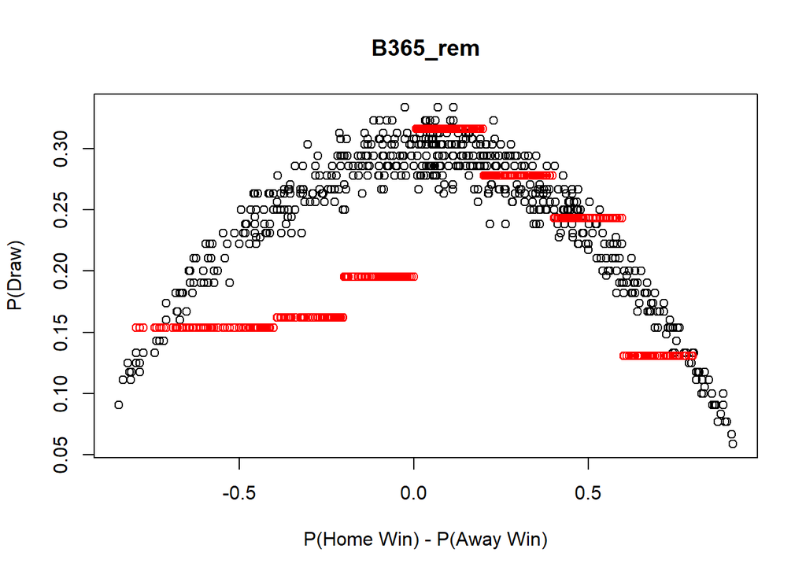

```r
plot(x = (PLdata_rem$HAdiff_B365), y = PLdata_rem$p_B365D,
     xlab = "P(Home Win) - P(Away Win)", ylab = "P(Draw)", main = "B365_rem")
points(x = PLdata_rem$HAdiff_B365, y = PLdata_rem$bin_draw_prob_B365, col = "red")
```

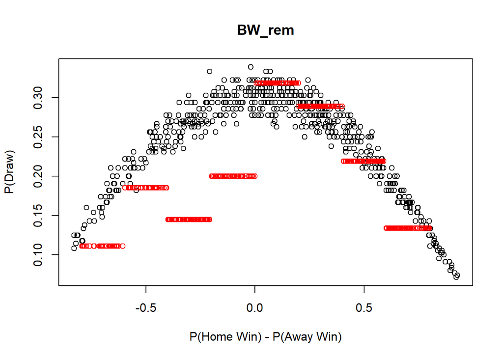

```r
plot(x = (PLdata_rem$HAdiff_BW), y = PLdata_rem$p_BWD,
     xlab = "P(Home Win) - P(Away Win)", ylab = "P(Draw)", main = "BW_rem")
points(x = PLdata_rem$HAdiff_BW, y = PLdata_rem$bin_draw_prob_BW, col = "red")
```

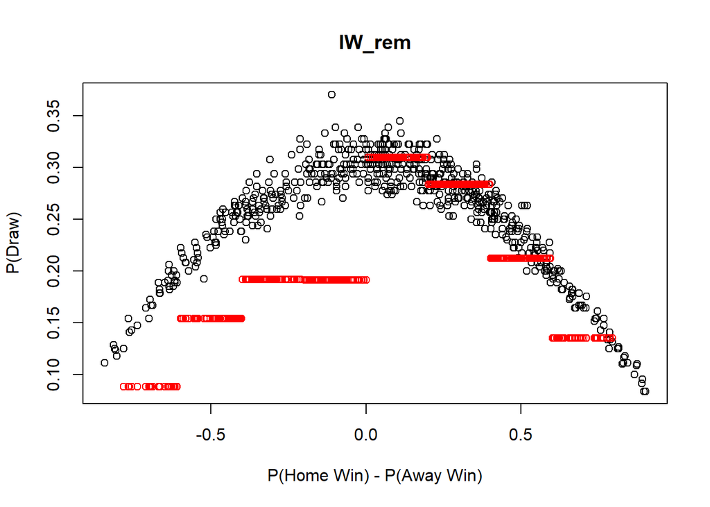

```r
plot(x = (PLdata_rem$HAdiff_IW), y = PLdata_rem$p_IWD,
     xlab = "P(Home Win) - P(Away Win)", ylab = "P(Draw)", main = "IW_rem")
points(x = PLdata_rem$HAdiff_IW, y = PLdata_rem$bin_draw_prob_IW, col = "red")
```

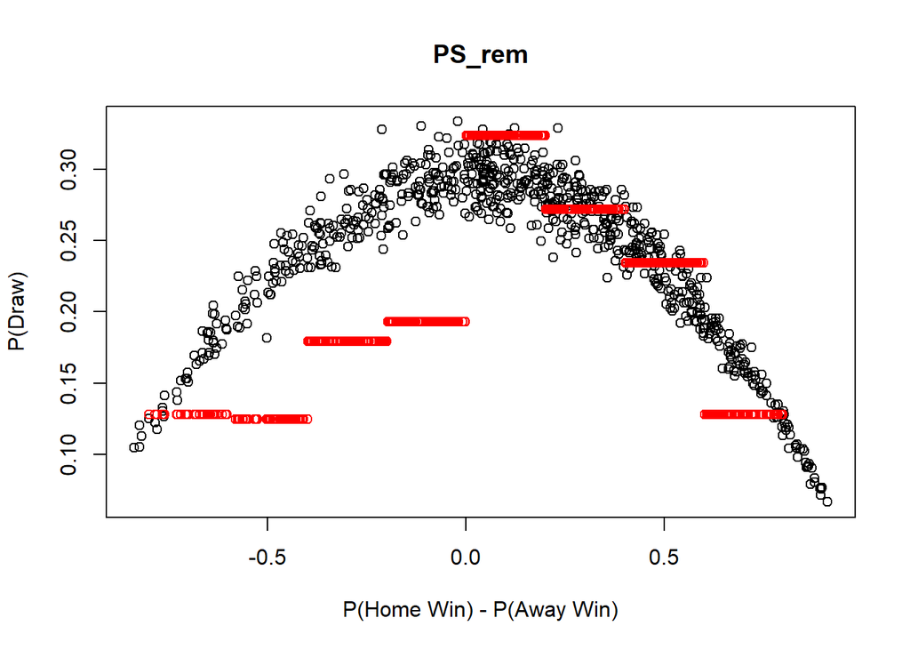

```r
plot(x = (PLdata_rem$HAdiff_PS), y = PLdata_rem$p_PSD,
     xlab = "P(Home Win) - P(Away Win)", ylab = "P(Draw)", main = "PS_rem")
points(x = PLdata_rem$HAdiff_PS, y = PLdata_rem$bin_draw_prob_PS, col = "red")
```

When the matches where red cards are shown by the referees are taken out of the data in order to avoid noise, not a significant difference is observed on the plots in terms of the positions of real probabilities and bookmakers’. At some companies and particular bins, some differences which could be evaluated as big are seen, however, no clear relationship is observed. No conclusion about the red cards favoring betters or bookmakers is achieved.